# P1: Test a Perceptual Phenomenon

Statistics: The Science of Decisions Project Instructions

**Background Information**

In a Stroop task, participants are presented with a list of words, with each word displayed in a color of ink. The participant’s task is to say out loud the color of the ink in which the word is printed. The task has two conditions: a congruent words condition, and an incongruent words condition. In the congruent words condition, the words being displayed are color words whose names match the colors in which they are printed: for example RED, BLUE. In the incongruent words condition, the words displayed are color words whose names do not match the colors in which they are printed: for example PURPLE, ORANGE. In each case, we measure the time it takes to name the ink colors in equally-sized lists. Each participant will go through and record a time from each condition. Questions For Investigation As a general note, be sure to keep a record of any resources that you use or refer to in the creation of your project. You will need to report your sources as part of the project submission.

**1. What is our independent variable? What is our dependent variable?**

The independent variables are categorical variables assuming the congruent words or incongruent words condition. The dependent variable is the time input each person report for each (in)congrency condition.

**2. What is an appropriate set of hypotheses for this task? What kind of statistical test do you expect to perform? Justify your choices.**

Time users report to complete the incongruent words condition is significantly larger than it is to complete the congruent words condition, comparing the average means of the two conditions we will measure if they’re significantly different at a chosen significance level to attest the existence of the Stroop Effect.

*Null Hypothesis*

The null hypothesis for this experiment will assume there’s no difference on the mean times for each condition, meaning that people usually take the same time to accomplish the tests regardless of (color name,color) congruency.

H0: $\mu$D = $\mu$C - $\mu$I = 0; The mean time of the congruent word condition is equal to the mean time of the incongruent word condition.

The population mean of the differences ($\mu$D) is equal (not significantly different) to the hypothesized mean of the differences ($\mu$D = 0).

*Alternative Hypothesis*

The alternative hypothesis for this experiment will assume users report less time under the congruent condition when compared to the time reported under the incongruent condition.

$\mu$C: Population mean for the time taken to read and speak out loud the correct answer under the congruent condition.

$\mu$I: Population mean for the time taken to read and speak out loud the correct answer under the incongruent condition.

*Proposed Statistical Test*

The chosen statistical test for this experiment is the T-Test.

Data Limitations:

- < 30 samples.
- Unknown population’s standard deviation.

Assumptions:

- Samples are radomly collected from each population.
- Dependent variable (time reported) is measured on a continous scale given in seconds.
- Independent variable (condition type) consists of two categorical related groups (same individuals took each test/repeated measure).
- Difference score are normally distributed (Gaussian).
- There’s no significant outliers in the difference between the Congruent and Incongruent condition.

*Known Lurking Variables*

In the controlled environment described, the process each person go through is by taking two tests one after the other in a particular order (congruent condition first and then incongruent condition right after). We can re-arrange the same controlled experience in other ways to better understand if there’s significant correlation between the test order and number of tests taken and the time reported. Possible scenarios would be:

S1: Person takes only one test: Congruent condition.

S2: Person takes only one test: Incongruent condition.

S3: Person takes two tests: Congruent Condition first, then Incongruent Condition.

S4: Person takes two tests: Incongruent Condition first, then Congruent Condition.

Exploring data from this full set of experiments we would be able to better understand if this two properties affect the time reported and can potentially show if there’s a bias under certain circumstances.

**3. Report some descriptive statistics regarding this dataset. Include at least one measure of central tendency and at least one measure of variability.**

```r
library('ggplot2')
library('gridExtra')
library(scales)
library(reshape2)
df <- read.csv("memory_scores.csv")
descriptive <- function(arg){
n <- length(arg)
min <- min(arg)
qt1 <- unname(quantile(arg,probs=0.25))
mean <- mean(arg)
median <- median(arg)
qt2 <- unname(quantile(arg,probs=0.75))
max <- max(arg)
var <- var(arg)
SD <- sd(arg)
return(c(n,min,qt1,mean,median,qt2,max,var,SD))
}
istats <- data.frame(descriptive(df$Congruent),
                     descriptive(df$Incongruent))
names(istats) <- c("Congruent","Incongruent")
row.names(istats) <- c("Sample Size","Minimum","Lower Quartile (25%)","Mean","Median","Upper Quartile (75%)","Maximum","Variance","Standard Deviation")
print.data.frame(istats)
```

|  | Congruent | Incongruent |
| --- | --- | --- |
| Sample Size | 24.000000 | 24.000000 |
| Minimum | 8.630000 | 15.687000 |
| Lower Quartile (25%) | 11.895250 | 18.716750 |
| Mean | 14.051125 | 22.015917 |
| Median | 14.356500 | 21.017500 |
| Upper Quartile (75%) | 16.200750 | 24.051500 |
| Maximum | 22.328000 | 35.255000 |
| Variance | 12.669029 | 23.011757 |
| Standard Deviation | 3.559358 | 4.797057 |

**4. Provide one or two visualizations that show the distribution of the sample data. Write one or two sentences noting what you observe about the plot or plots.**

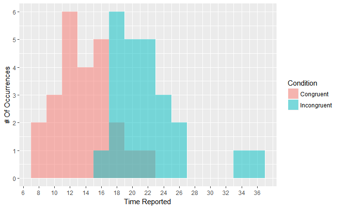

```r
#Reshaping Data
df2 <- t(df)
df2 <- melt(df2, id=c("v1"))
df2$Var2 <- NULL
colnames(df2)=c("Condition","Time_Reported")
ggplot(data=df2,aes(x=df2$Time_Reported,fill=Condition))+
  geom_histogram(binwidth=2,alpha=0.5,position = 'identity')+
  scale_x_continuous(breaks=seq(0,36,2))+
  scale_y_continuous(breaks=seq(0,6,1))+
  ylab("# Of Occurrences")+
  xlab("Time Reported")
```

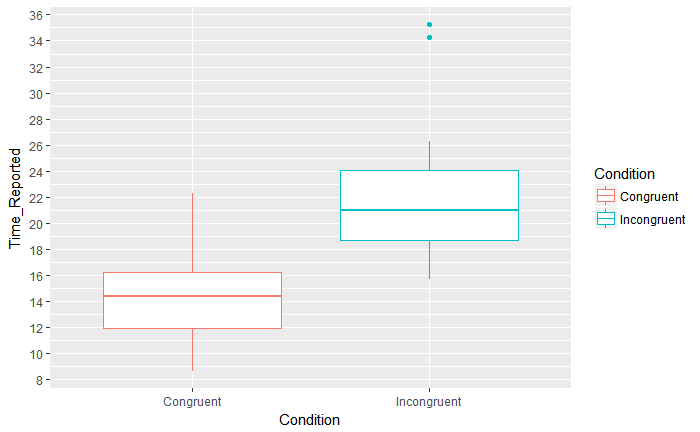

```r
ggplot(data=df2,aes(x=Condition,y=Time_Reported,color=Condition))+
  geom_boxplot()+
  scale_y_continuous(breaks=seq(0,36,2))
```

The histograms intercept occurs between the right tail region of the Congruent condition and the left tail of the Incongruent condition, showing that the Incongruent condition (indeed) seems to take significantly more time to complete than the Congruent condition.

**5. Now, perform the statistical test and report your results. What is your confidence level and your critical statistic value? Do you reject the null hypothesis or fail to reject it? Come to a conclusion in terms of the experiment task. Did the results match up with your expectations?**

*Test Overall Information*

Test if treatment has signifcant impact on time reported with a dependent t-test for paired samples

Pre-treatment: Congruent words condition Post-treatment: Incongruent words condition.

```r
t.test(df$Congruent, df$Incongruent,alternative="less",mu=0,paired=TRUE,var.eq=FALSE,conf.level=0.95)
```

```
    Paired t-test

data:  df$Congruent and df$Incongruent
t = -8.0207, df = 23, p-value = 2.052e-08
alternative hypothesis: true difference in means is less than 0
95 percent confidence interval:
      -Inf -6.262868
sample estimates:
mean of the differences
              -7.964792
```

The p-value is the probability below the negative value of the t-statistic, Since it’s less than the alpha level we reject the null hypothesis, such result matches the initial expectation.

Another way to look at the provided result is to compare the t-critical value with the t-statistic, as the t-statistic is out of the t-critical value boundary it gives us enough information to reject the null hypothesis for the entire population.

**6. Optional: What do you think is responsible for the effects observed? Can you think of an alternative or similar task that would result in a similar effect? Some research about the problem will be helpful for thinking about these two**

Probably there’s a natural intuitive brain issue for this type of situation, the observed effect occurs due conflicting information between the name of the color and the color it’s filled with, the brain might recognize the word that is written before it recognizes the color of the written word.

Although this is only a hypothesis, if that’s true it can explain the brain “lag” observed in the incongruent words condition, where overall the time reported is greater than the ones under the congruent words condition. If this hypothesis is false, is still possible that the order the brain recognizes attributes doesn’t matter but it highlights the written name by default and not the color (bias), causing conflict when attempting to fast and accurately report the color each word is filled with.